# MQuinho de inverno - R para análise de dados (script)

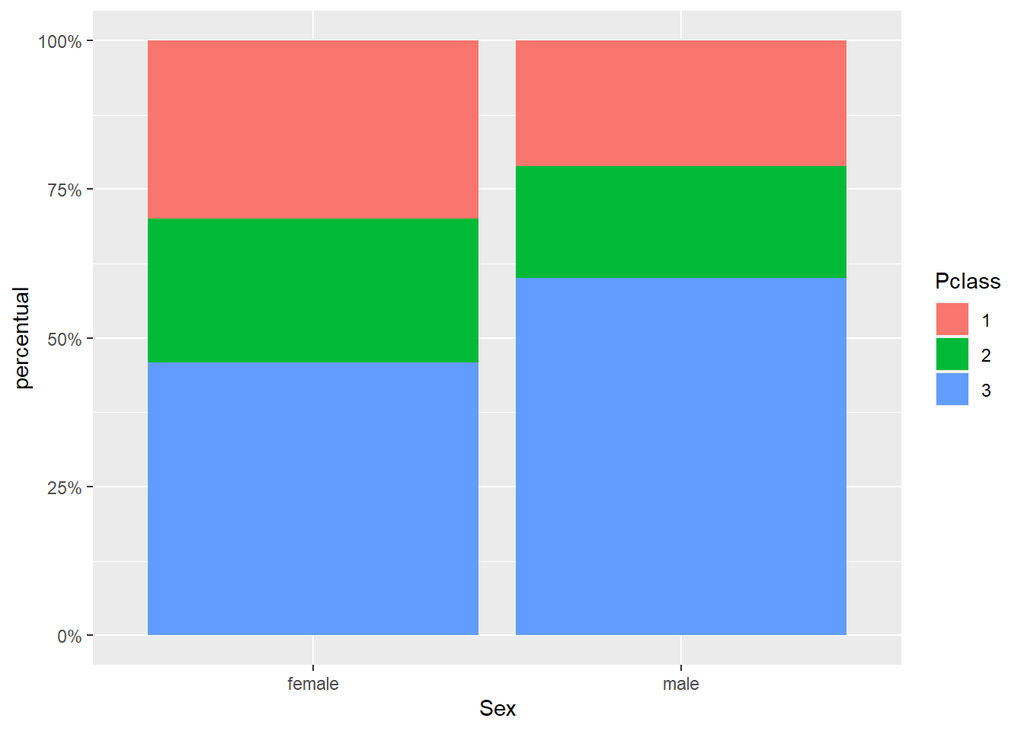

```r
#Barras empilhadas
frequencia_perc_sexoticket %>%
  ggplot(mapping = aes(x = Sex,
                       y = percentual,
                       fill = Pclass)) +
  geom_col() +
  scale_y_continuous(label = percent)
```

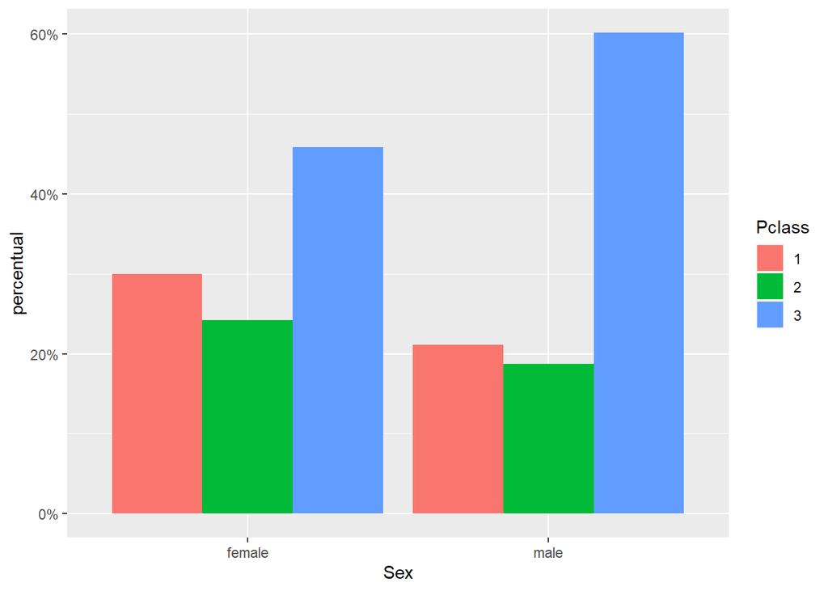

```r
#Barras lado-a-lado
frequencia_perc_sexoticket %>%
  ggplot(mapping = aes(x = Sex,
                       y = percentual,
                       fill = Pclass)) +
  geom_col(position = 'dodge') +
  scale_y_continuous(label = percent)
```

```r
class(frequencia_perc_sexoticket$Sex)
```

```
## [1] "factor"
```

**Alguns melhoramentos estéticos para o gráfico: Sexo X Ticket**

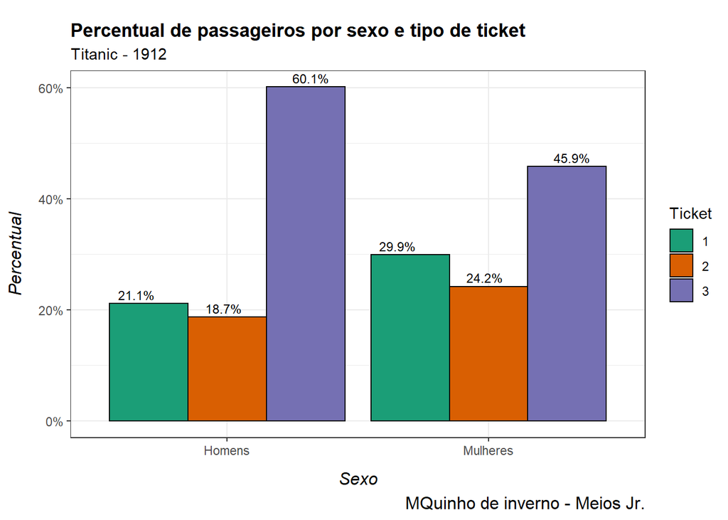

```r
# Criando um label para colocar acima das barras do gráfico, alterando informações previamente a plotagem
frequencia_perc_sexoticket <- frequencia_perc_sexoticket %>%
  mutate(label = percent(percentual),
         sexo_plot = case_when(Sex == 'female' ~ 'Mulheres',
                               Sex == 'male' ~ 'Homens'))

# O Código do gráfico
frequencia_perc_sexoticket %>%
  ggplot(mapping = aes(x = sexo_plot,
                       y = percentual,
                       fill = Pclass,
                       label = label)) +             # Novidade
  geom_col(position = 'dodge',
           colour = 'grey3') +
  geom_text(position = position_dodge(width = 1),    # Novidade
            vjust = -0.4,
            size = 3.2,
            hjust = 0.6) +
  scale_y_continuous(label = percent) +
  scale_fill_brewer(palette = 'Dark2') +
  theme_bw() +
  labs(title = "Percentual de passageiros por sexo e tipo de ticket",  # Novidade
       subtitle = 'Titanic - 1912',
       x = 'Sexo',
       y = 'Percentual',
       fill = 'Ticket',
       caption = 'MQuinho de inverno - Meios Jr.') +
  theme(plot.title = element_text(face = "bold",                       # Novidade
                                  margin = margin(10, 0, 5, 0),
                                  size = 13),
        axis.title.x = element_text(margin = margin(t = 10),
                                    size = 12,
                                    face = 'italic'),
        axis.title.y = element_text(margin = margin(r = 10),
                                    size = 12,
                                    face = 'italic'),
        plot.caption = element_text(size = 12))
```

#### 10.2.2. Histogramas

O histograma é um dos tipos de gráfico mais apropriados para mostrar a distribuição de frequências de uma variável numérica. A estatística padrão (stat) dos histogramas é o stat_bin.

**Idade no banco de dados**

**Histograma simples**

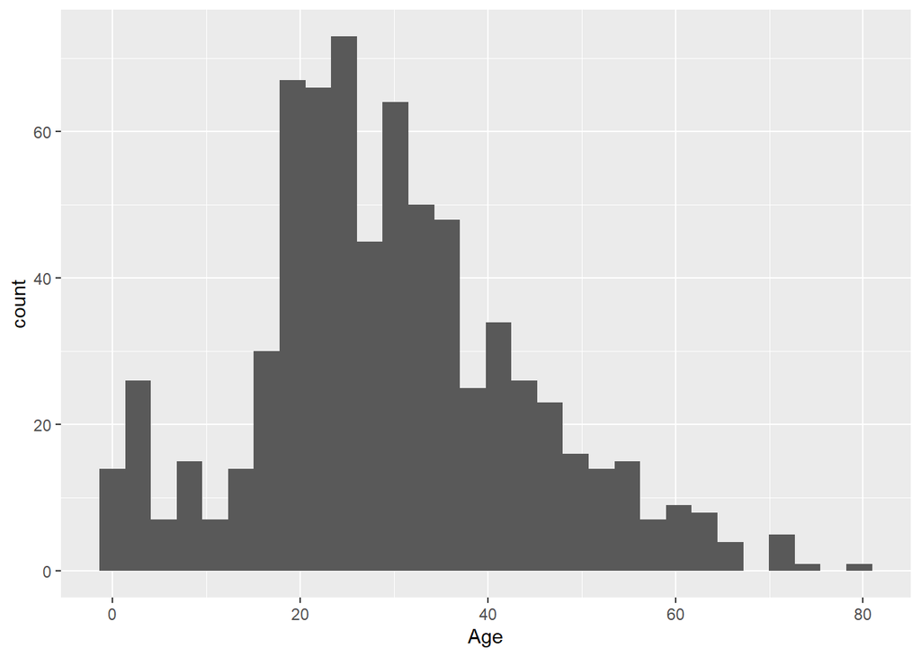

```r
# Função padrão
titanic %>%
  ggplot(mapping = aes(x = Age)) +
  geom_histogram()
```

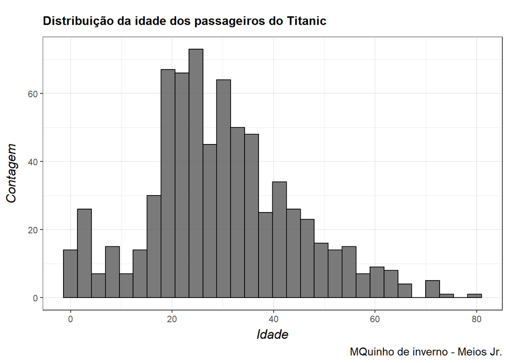

```r
# Estética
titanic %>%
  ggplot(mapping = aes(x = Age)) +
  geom_histogram(alpha = 0.8,
                 colour = 'black') +
  theme_bw() +
  labs(title = 'Distribuição da idade dos passageiros do Titanic',
       y = 'Contagem',
       x = 'Idade',
       caption = "MQuinho de inverno - Meios Jr.") +
  theme(plot.title = element_text(face = "bold",
                                  margin = margin(10, 0, 10, 0),
                                  size = 12),
        axis.title.x = element_text(margin = margin(t = 5),
                                    size = 13,
                                    face = 'italic'),
        axis.title.y = element_text(margin = margin(r = 10),
                                    size = 13,
                                    face = 'italic'),
        plot.caption = element_text(size = 11))
```

**Histograma utilizando densidade + curva de densidade**

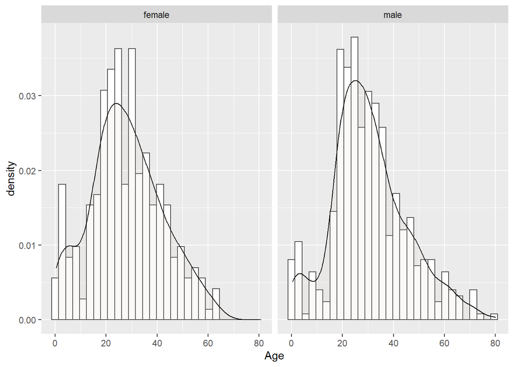

```r
# Argumento base
titanic %>%
  ggplot(mapping = aes(x = Age)) +
  geom_histogram(aes(y = ..density..),
                 colour = "grey30",
                 fill = "white") +
  geom_density(alpha = .1,
               fill = "antiquewhite3") +
  facet_wrap(~Sex)
```

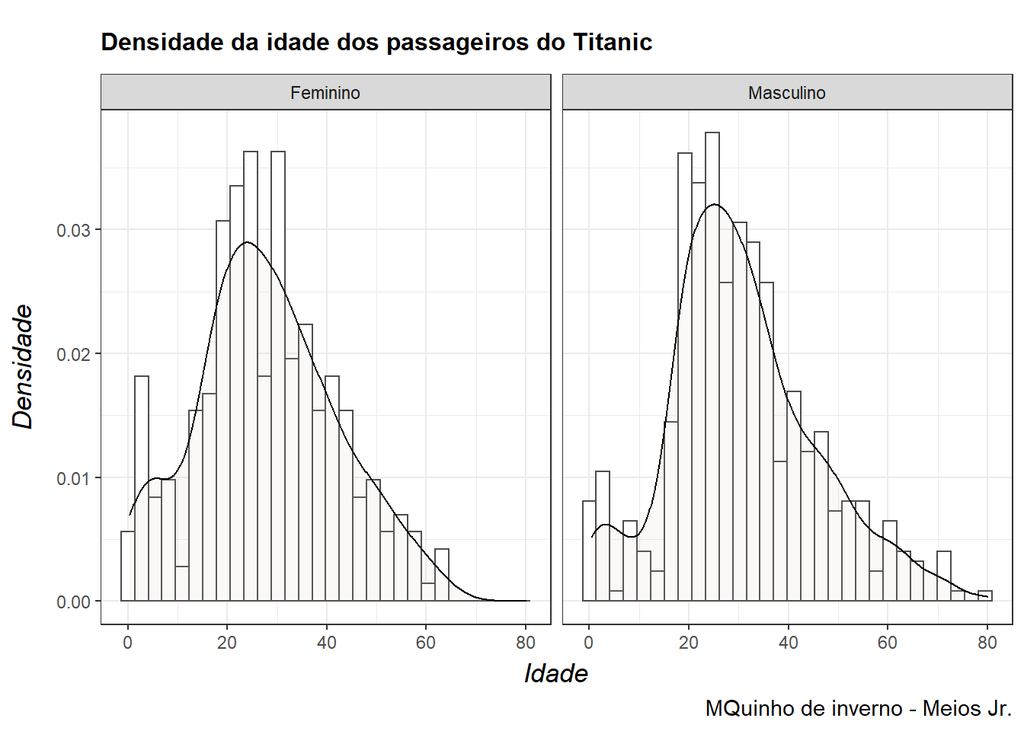

```r
# Estética
titanic %>%
  mutate(Sexo = case_when(Sex == 'female' ~ 'Feminino',
                          Sex == 'male' ~ 'Masculino')) %>%
  ggplot(mapping = aes(x = Age)) +
  geom_histogram(aes(y = ..density..),
                 colour = "grey30",
                 fill = "white") +
  geom_density(alpha = .1,
               fill = "antiquewhite3") +
  facet_wrap(~Sexo) +
  theme_bw() +
  labs(title = 'Densidade da idade dos passageiros do Titanic',
       y = 'Densidade',
       x = 'Idade',
       caption = "MQuinho de inverno - Meios Jr.") +
  theme(plot.title = element_text(face = "bold",
                                  margin = margin(10, 0, 10, 0),
                                  size = 12),
        axis.title.x = element_text(margin = margin(t = 5),
                                    size = 13,
                                    face = 'italic'),
        axis.title.y = element_text(margin = margin(r = 10),
                                    size = 13,
                                    face = 'italic'),
        plot.caption = element_text(size = 11))
```

#### 10.2.3. Boxplots

O boxplot é um dos gráficos mais úteis para as Ciências Sociais, em minha opinião. Com ele podemos identificar a relação entre uma variável categórica e outra contínua, identificando seus quartis, mediana, outliers, etc, para cada grupo da variável categórica em questão.

**Boxplot simples: idade por sexo**

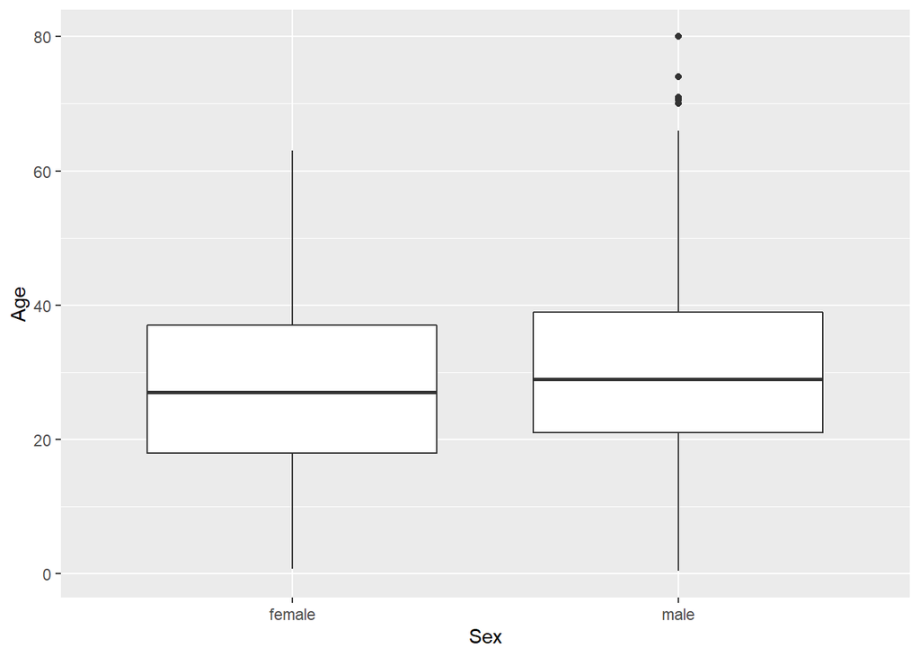

```r
titanic %>%
  ggplot(mapping = aes(x = Sex,
                       y = Age)) +
  geom_boxplot()
```

**Boxplot com duas variáveis: idade por sexo e tipo de ticket**

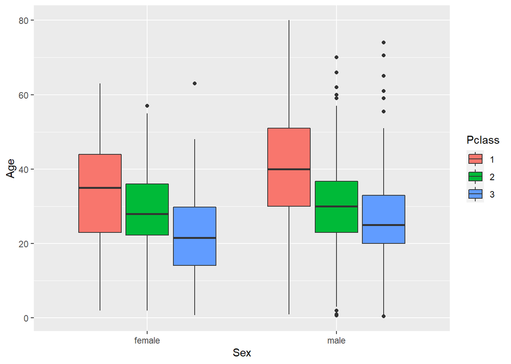

```r
titanic %>%
  ggplot(mapping = aes(x = Sex,
                       y = Age,
                       fill = Pclass)) +
  geom_boxplot()
```

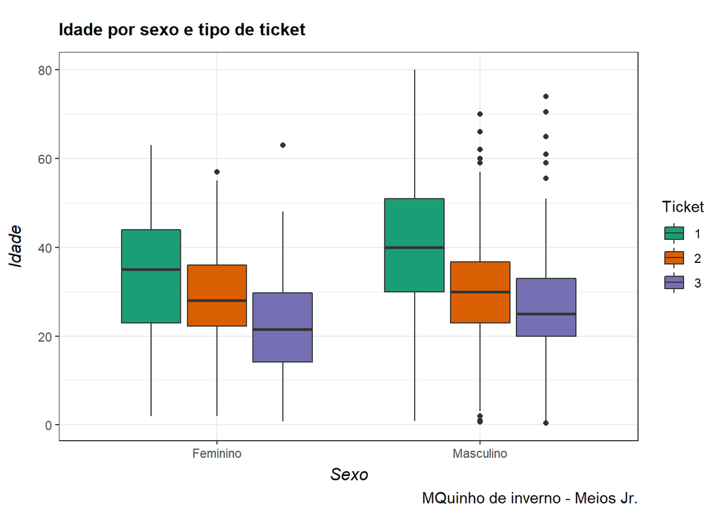

```r
## Estética

titanic %>%
  mutate(Sexo = case_when(Sex == 'female' ~ 'Feminino',
                          Sex == 'male' ~ 'Masculino')) %>%
  ggplot(mapping = aes(x = Sexo,
                       y = Age,
                       fill = Pclass)) +
  geom_boxplot() +
  theme_bw() +
  scale_fill_brewer(palette = 'Dark2') +
  labs(title = 'Idade por sexo e tipo de ticket',
       y = 'Idade',
       x = 'Sexo',
       fill = 'Ticket',
       caption = "MQuinho de inverno - Meios Jr.") +
  theme(plot.title = element_text(face = "bold",
                                  margin = margin(10, 0, 10, 0),
                                  size = 12),
        axis.title.x = element_text(margin = margin(t = 5),
                                    size = 12,
                                    face = 'italic'),
        axis.title.y = element_text(margin = margin(r = 10),
                                    size = 12,
                                    face = 'italic'),
        plot.caption = element_text(size = 11))
```

#### 10.2.4. Diagramas de dispersão (gráficos de pontos)

O diagrama de dispersão, também conhecido como gráfico de pontos ou scatterplot é o principal tipo de gráfico utilizado para mensuração de duas variáveis contínuas. Cada ponto representa a intersecção entre X e Y.

```r
# Banco de dados utilizado

crimes_eua <- USArrests
```

**Gráfico de pontos simples: número de assassinatos e ocorrências violentas**

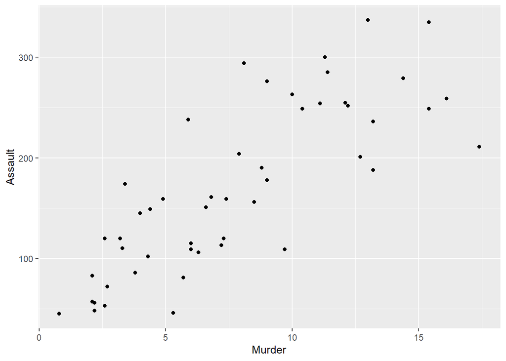

```r
# Ocorrências violentas e assassinatos
crimes_eua %>%
  ggplot(mapping = aes(x = Murder,
                       y = Assault)) +
  geom_point()
```

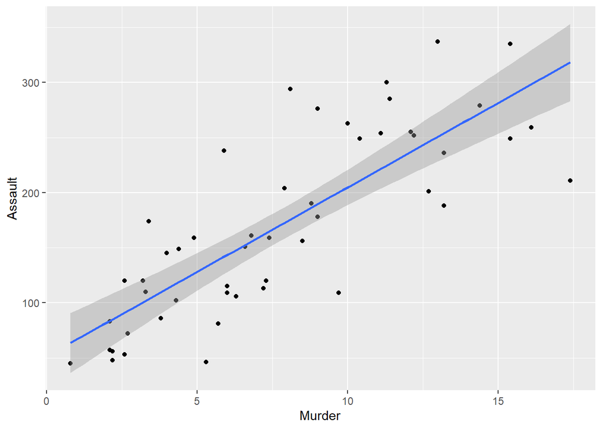

```r
# Adicionando uma linha de suavização
crimes_eua %>%
  ggplot(mapping = aes(x = Murder,
                       y = Assault)) +
  geom_point() +
  geom_smooth(method = 'lm')
```

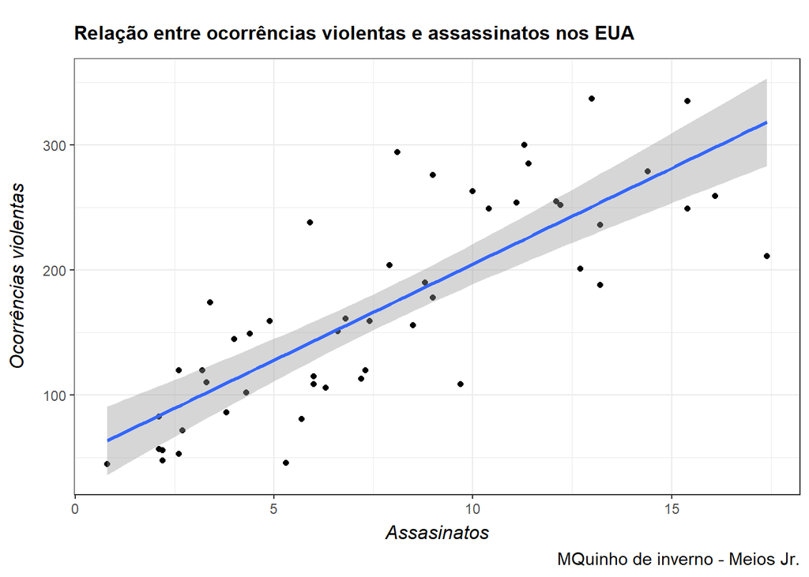

```r
# Estética
crimes_eua %>%
  ggplot(mapping = aes(x = Murder,
                       y = Assault)) +
  geom_point() +
  geom_smooth(method = 'lm')+
  scale_color_brewer(palette = 'Dark2')+
  labs(title = 'Relação entre ocorrências violentas e assassinatos nos EUA',
       y = 'Ocorrências violentas',
       x = 'Assasinatos',
       caption = "MQuinho de inverno - Meios Jr.") +
  theme_bw() +
  theme(plot.title = element_text(face = "bold",
                                  margin = margin(10, 0, 10, 0),
                                  size = 12),
        axis.title.x = element_text(margin = margin(t = 5),
                                    size = 12,
                                    face = 'italic'),
        axis.title.y = element_text(margin = margin(r = 10),
                                    size = 12,
                                    face = 'italic'),
        plot.caption = element_text(size = 11))
```

**Homenagem ao Gendson: Gráfico de pontos: comprimento da pétala x largura da pétala (IRIS)**

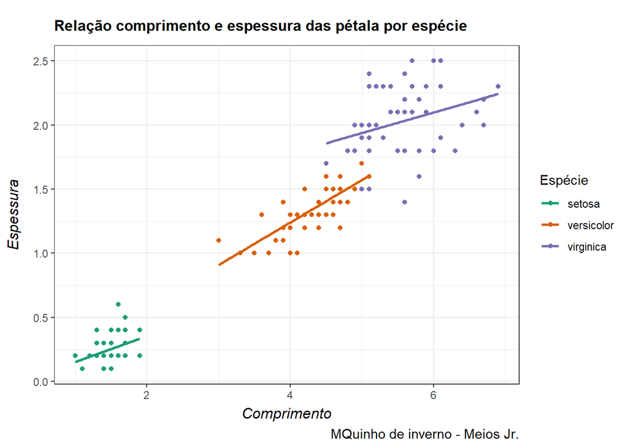

```r
iris %>%
  ggplot(mapping = aes(x = Petal.Length,
                       y =  Petal.Width,
                       colour = Species)) +
  geom_point() +
  geom_smooth(se = F,
              method = 'lm') +
  scale_color_brewer(palette = 'Dark2')+
  labs(title = 'Relação comprimento e espessura das pétala por espécie',
       y = 'Espessura',
       x = 'Comprimento',
       colour = 'Espécie',
       caption = "MQuinho de inverno - Meios Jr.") +
  theme_bw() +
  theme(plot.title = element_text(face = "bold",
                                  margin = margin(10, 0, 10, 0),
                                  size = 12),
        axis.title.x = element_text(margin = margin(t = 5),
                                    size = 12,
                                    face = 'italic'),
        axis.title.y = element_text(margin = margin(r = 10),
                                    size = 12,
                                    face = 'italic'),
        plot.caption = element_text(size = 11))
```

#### 10.2.5. Gráfico de linhas

Os gráficos de linhas são particularmente uteis quando a intenção é demonstrar a progressão de um fenômeno em diferentes períodos de tempo.

**O banco de dados:**

```r
# Banco original

anos <- c(1980, 1990, 2000)
sexo <- c('Mulher', 'Mulher', 'Mulher', 'Homem', 'Homem', 'Homem')
rendimentos <- c(600, 700, 800, 650, 750, 900)

banco_salario <- data.frame(anos, sexo, rendimentos)
```

**Gráfico de linhas:**

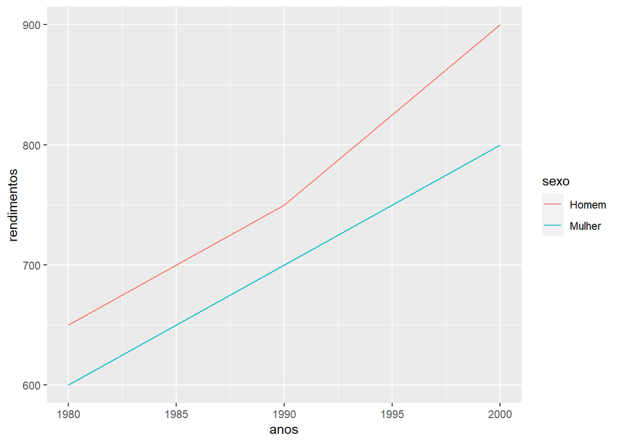

```r
# Estrutura
banco_salario %>%
  ggplot(mapping = aes(x = anos,
                       y = rendimentos,
                       colour = sexo)) +
  geom_line()
```

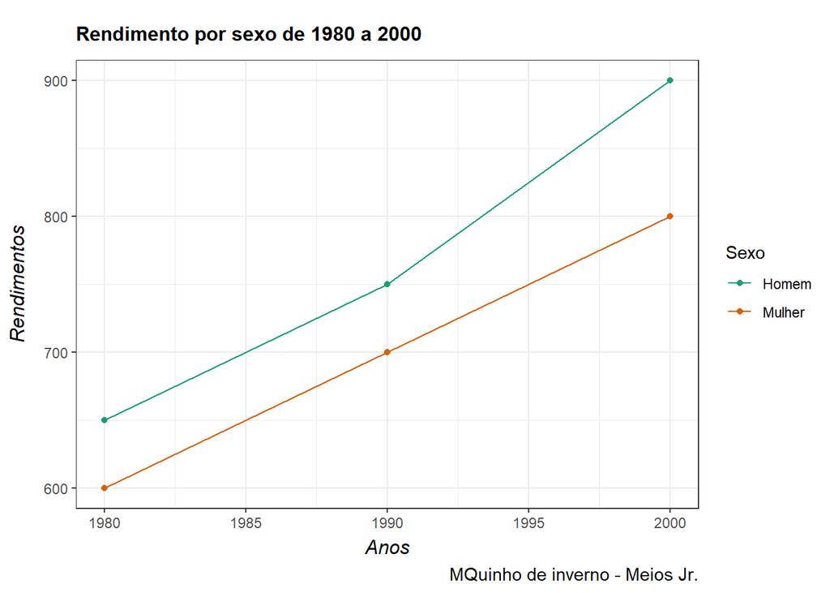

```r
# Estética
banco_salario %>%
  ggplot(mapping = aes(x = anos,
                       y = rendimentos,
                       colour = sexo)) +
  geom_line() +
  geom_point() +
  theme_bw() +
  scale_colour_brewer(palette = 'Dark2') +
  labs(title = 'Rendimento por sexo de 1980 a 2000',
       y = 'Rendimentos',
       x = 'Anos',
       caption = "MQuinho de inverno - Meios Jr.",
       colour = 'Sexo') +
  theme(plot.title = element_text(face = "bold",
                                  margin = margin(10, 0, 10, 0),
                                  size = 12),
        axis.title.x = element_text(margin = margin(t = 5),
                                    size = 12,
                                    face = 'italic'),
        axis.title.y = element_text(margin = margin(r = 10),
                                    size = 12,
                                    face = 'italic'),
        plot.caption = element_text(size = 11))
```